# Selling SPY Weeklys: 2014 - 2018

Strangles vs Puts

Pritam Dalal

February 7, 2019

The purpose of this analysis is to compare the strategies of selling puts and selling strangles.

Both strategies will utilize the following risk-management:

1. 10% threshold delta-hedging
2. 300% loss-trigger position unwinds.

My conclusion is that the strategies are similar, but selling strangles has a a higher Sharpe-Ratio, so I recommend sticking with strangle selling.

#### Overall Peformance

The two strategies had nearly identical performance from the point of view of pnl/return. However, selling puts had greater variability and thus a significantly lower Sharpe-Ratio.

| strategy | total_pnl | stdev_pnl | sharpe |
| --- | --- | --- | --- |
| put | 15.98 | 3.26 | 0.98 |
| strangle | 16.20 | 2.59 | 1.25 |

#### Visualizing Cumulative Performance

The performance of the two strategies can be contrasted by observing the cumulative performance graph:

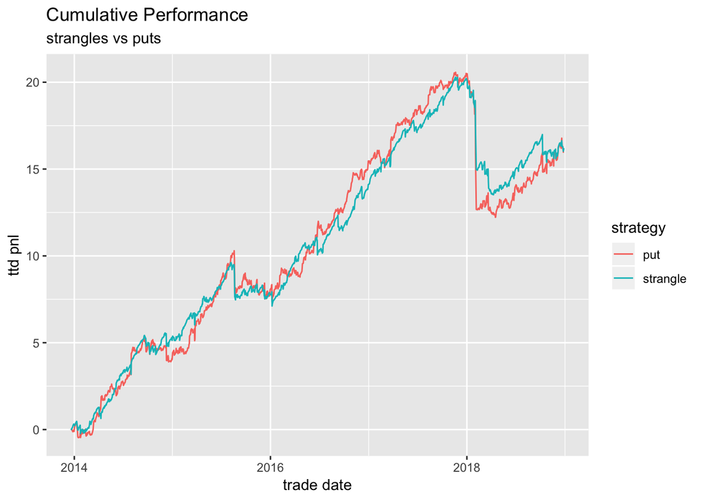

The selling of puts has greater variability. In particular, the draw-down in early 2018 is more significant for puts than for strangles.

#### Performance by Year

It is instructive to analyze performance of each strategy by year. Although there are certain years in which puts outperform strangles both in terms of returns and Sharpe, overall strangles is a better strategy.

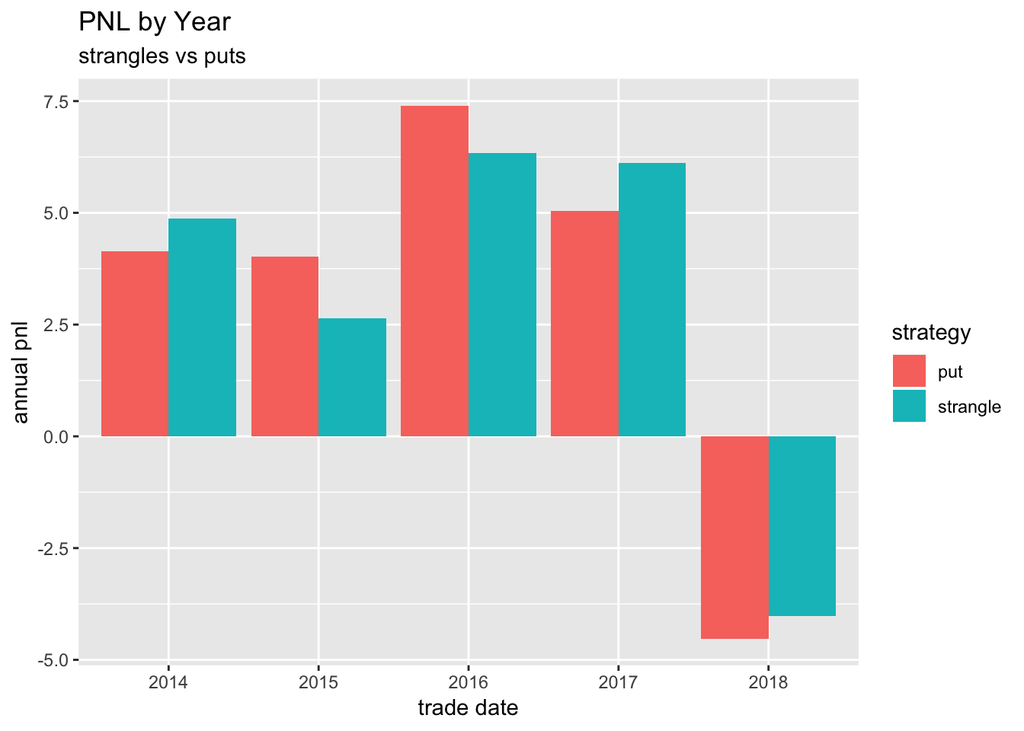

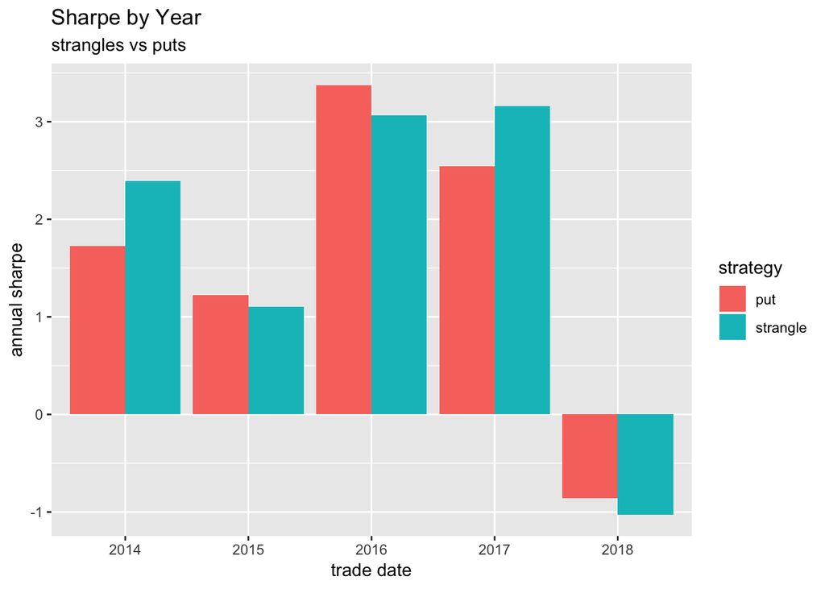

#### Conclusion & Recommendation

Due to superior risk-adjusted performance, my recommendation is to focus on strangles rather than puts. All of my subsequent analysis will be on selling strangles only.